# Project 2 Technical Report

## Social Media and Mental Health

Haoran Chen | DTSC 2301 | Spring 2026

Portfolio post: project2.html

GitHub: github.com/hchen34-creater/dtsc2301-portfolio

## Introduction

I wanted to look at whether you can predict someones mental health based on how they use social media. Theres been alot of news about this, especially with the lawsuit in March 2026 where a jury found Meta and Google liable and ordered them to pay $6 million to a woman who said social media messed up her mental health as a kid. Theres like 1500 more cases waiting.

My research question: can we predict whether a person has high or low mental health impact from their social media usage, and which behaviors matter most.

My partner helped me narrow this down. We originally wanted to look at social media addiction in general but that was too broad so we focused on distraction, sleep, and comparing yourself to others.

## Dataset

"Social Media and Mental Health" from Kaggle by Souvik Ahmed. 481 survey responses, 20 questions. Has demographics, social media habits, and mental health questions on a 1-5 scale.

https://www.kaggle.com/datasets/souvikahmed071/social-media-and-mental-health

I picked this one because it had both social media and mental health data together so I could try to predict one from the other.

```python
import pandas as pd
import numpy as np
import seaborn as sns
import matplotlib.pyplot as plt
from sklearn.model_selection import train_test_split, cross_val_score
from sklearn.preprocessing import StandardScaler
from sklearn.linear_model import LogisticRegression
from sklearn.tree import DecisionTreeClassifier
from sklearn.ensemble import RandomForestClassifier
from sklearn.metrics import classification_report, confusion_matrix
```

```python
df = pd.read_csv('https://raw.githubusercontent.com/hchen34-creater/dtsc2301-portfolio/refs/heads/main/smmh.csv')
```

```python
df = pd.read_csv('smmh.csv')
df.head()
```

|  | Timestamp | 1. What is your age? | 2. Gender | 3. Relationship Status | 4. Occupation Status | 5. What type of organizations are you affiliated with? | 6. Do you use social media? | 7. What social media platforms do you commonly use? | 8. What is the average time you spend on social media every day? | 9. How often do you find yourself using Social media without a specific purpose? | ... | 11. Do you feel restless if you haven't used Social media in a while? | 12. On a scale of 1 to 5, how easily distracted are you? | 13. On a scale of 1 to 5, how much are you bothered by worries? | 14. Do you find it difficult to concentrate on things? | 15. On a scale of 1-5, how often do you compare yourself to other successful people through the use of social media? | 16. Following the previous question, how do you feel about these comparisons, generally speaking? | 17. How often do you look to seek validation from features of social media? | 18. How often do you feel depressed or down? | 19. On a scale of 1 to 5, how frequently does your interest in daily activities fluctuate? | 20. On a scale of 1 to 5, how often do you face issues regarding sleep? |
| --- | --- | --- | --- | --- | --- | --- | --- | --- | --- | --- | --- | --- | --- | --- | --- | --- | --- | --- | --- | --- | --- |
| 0 | 4/18/2022 19:18:47 | 21.0 | Male | In a relationship | University Student | University | Yes | Facebook, Twitter, Instagram, YouTube, Discord... | Between 2 and 3 hours | 5 | ... | 2 | 5 | 2 | 5 | 2 | 3 | 2 | 5 | 4 | 5 |
| 1 | 4/18/2022 19:19:28 | 21.0 | Female | Single | University Student | University | Yes | Facebook, Twitter, Instagram, YouTube, Discord... | More than 5 hours | 4 | ... | 2 | 4 | 5 | 4 | 5 | 1 | 1 | 5 | 4 | 5 |
| 2 | 4/18/2022 19:25:59 | 21.0 | Female | Single | University Student | University | Yes | Facebook, Instagram, YouTube, Pinterest | Between 3 and 4 hours | 3 | ... | 1 | 2 | 5 | 4 | 3 | 3 | 1 | 4 | 2 | 5 |
| 3 | 4/18/2022 19:29:43 | 21.0 | Female | Single | University Student | University | Yes | Facebook, Instagram | More than 5 hours | 4 | ... | 1 | 3 | 5 | 3 | 5 | 1 | 2 | 4 | 3 | 2 |
| 4 | 4/18/2022 19:33:31 | 21.0 | Female | Single | University Student | University | Yes | Facebook, Instagram, YouTube | Between 2 and 3 hours | 3 | ... | 4 | 4 | 5 | 5 | 3 | 3 | 3 | 4 | 4 | 1 |

5 rows × 21 columns

```python
df.shape
```

```
(481, 21)
```

```python
# renaming columns because the originals are the full survey questions
# like "1. What is your age?" which is annoying to type every time
df.columns = [
    'Timestamp', 'Age', 'Gender', 'Relationship', 'Occupation', 'Organization',
    'Uses_SM', 'Platforms', 'Avg_Time', 'Purposeless', 'Distracted_Busy',
    'Restless', 'Easily_Distracted', 'Bothered_Worries', 'Hard_Concentrate',
    'Compare_Others', 'Feel_Comparisons', 'Seek_Validation', 'Feel_Depressed',
    'Interest_Fluctuate', 'Sleep_Issues'
]
df.head()
```

|  | Timestamp | Age | Gender | Relationship | Occupation | Organization | Uses_SM | Platforms | Avg_Time | Purposeless | ... | Restless | Easily_Distracted | Bothered_Worries | Hard_Concentrate | Compare_Others | Feel_Comparisons | Seek_Validation | Feel_Depressed | Interest_Fluctuate | Sleep_Issues |
| --- | --- | --- | --- | --- | --- | --- | --- | --- | --- | --- | --- | --- | --- | --- | --- | --- | --- | --- | --- | --- | --- |
| 0 | 4/18/2022 19:18:47 | 21.0 | Male | In a relationship | University Student | University | Yes | Facebook, Twitter, Instagram, YouTube, Discord... | Between 2 and 3 hours | 5 | ... | 2 | 5 | 2 | 5 | 2 | 3 | 2 | 5 | 4 | 5 |
| 1 | 4/18/2022 19:19:28 | 21.0 | Female | Single | University Student | University | Yes | Facebook, Twitter, Instagram, YouTube, Discord... | More than 5 hours | 4 | ... | 2 | 4 | 5 | 4 | 5 | 1 | 1 | 5 | 4 | 5 |
| 2 | 4/18/2022 19:25:59 | 21.0 | Female | Single | University Student | University | Yes | Facebook, Instagram, YouTube, Pinterest | Between 3 and 4 hours | 3 | ... | 1 | 2 | 5 | 4 | 3 | 3 | 1 | 4 | 2 | 5 |
| 3 | 4/18/2022 19:29:43 | 21.0 | Female | Single | University Student | University | Yes | Facebook, Instagram | More than 5 hours | 4 | ... | 1 | 3 | 5 | 3 | 5 | 1 | 2 | 4 | 3 | 2 |
| 4 | 4/18/2022 19:33:31 | 21.0 | Female | Single | University Student | University | Yes | Facebook, Instagram, YouTube | Between 2 and 3 hours | 3 | ... | 4 | 4 | 5 | 5 | 3 | 3 | 3 | 4 | 4 | 1 |

5 rows × 21 columns

## Preprocessing

```python
df.isnull().sum()
```

|  | 0 |
| --- | --- |
| Timestamp | 0 |
| Age | 0 |
| Gender | 0 |
| Relationship | 0 |
| Occupation | 0 |
| Organization | 30 |
| Uses_SM | 0 |
| Platforms | 0 |
| Avg_Time | 0 |
| Purposeless | 0 |
| Distracted_Busy | 0 |
| Restless | 0 |
| Easily_Distracted | 0 |
| Bothered_Worries | 0 |
| Hard_Concentrate | 0 |
| Compare_Others | 0 |
| Feel_Comparisons | 0 |
| Seek_Validation | 0 |
| Feel_Depressed | 0 |
| Interest_Fluctuate | 0 |
| Sleep_Issues | 0 |

**dtype:** int64

Organization has 30 missing. Everthing else looks fine.

```python
# drop stuff I dont need
df = df.drop(columns=['Timestamp', 'Uses_SM'])
df = df.dropna()
print(df.shape)
```

```
(451, 19)
```

```python
# the time column is text so I need to convert it
df['Avg_Time'].value_counts()
```

| Avg_Time | count |
| --- | --- |
| More than 5 hours | 111 |
| Between 2 and 3 hours | 93 |
| Between 3 and 4 hours | 86 |
| Between 1 and 2 hours | 65 |
| Between 4 and 5 hours | 63 |
| Less than an Hour | 33 |

**dtype:** int64

```python
time_map = {
    'Less than an Hour': 0.5, 'Between 1 and 2 hours': 1.5,
    'Between 2 and 3 hours': 2.5, 'Between 3 and 4 hours': 3.5,
    'Between 4 and 5 hours': 4.5, 'More than 5 hours': 5.5
}
df['Avg_Time'] = df['Avg_Time'].map(time_map)

# gender too
df['Gender'] = df['Gender'].map({'Male': 0, 'Female': 1, 'Nonbinary': 2, 'Transgender': 2})

# count platforms
df['Num_Platforms'] = df['Platforms'].str.split(',').str.len()
```

```python
# drop text columns the model cant use
df = df.drop(columns=['Platforms', 'Organization', 'Relationship', 'Occupation'])
df = df.dropna()
print(df.shape)
df.head()
```

```
(446, 16)
```

|  | Age | Gender | Avg_Time | Purposeless | Distracted_Busy | Restless | Easily_Distracted | Bothered_Worries | Hard_Concentrate | Compare_Others | Feel_Comparisons | Seek_Validation | Feel_Depressed | Interest_Fluctuate | Sleep_Issues | Num_Platforms |
| --- | --- | --- | --- | --- | --- | --- | --- | --- | --- | --- | --- | --- | --- | --- | --- | --- |
| 0 | 21.0 | 0.0 | 2.5 | 5 | 3 | 2 | 5 | 2 | 5 | 2 | 3 | 2 | 5 | 4 | 5 | 6 |
| 1 | 21.0 | 1.0 | 5.5 | 4 | 3 | 2 | 4 | 5 | 4 | 5 | 1 | 1 | 5 | 4 | 5 | 6 |
| 2 | 21.0 | 1.0 | 3.5 | 3 | 2 | 1 | 2 | 5 | 4 | 3 | 3 | 1 | 4 | 2 | 5 | 4 |
| 3 | 21.0 | 1.0 | 5.5 | 4 | 2 | 1 | 3 | 5 | 3 | 5 | 1 | 2 | 4 | 3 | 2 | 2 |
| 4 | 21.0 | 1.0 | 2.5 | 3 | 5 | 4 | 4 | 5 | 5 | 3 | 3 | 3 | 4 | 4 | 1 | 3 |

I used .map() to convert the text columns because each value needed a specific number. Like "Between 2 and 3 hours" needs to become 2.5 not just some random label. For counting platforms I split the comma seperated list and counted how many items it had.

Dropped Timestamp because its just when they took the survey, and Uses_SM because literally everyone said yes. Also dropped text columns like Occupation and Relationship since the model cant read text.

### Target variable

The dataset doesnt have a label for mental health impact so I made one. I added 5 of the mental health questions together into a score.

```python
df['MH_Score'] = (df['Bothered_Worries'] + df['Hard_Concentrate'] +
                  df['Feel_Depressed'] + df['Interest_Fluctuate'] + df['Sleep_Issues'])

print(f'Min: {df["MH_Score"].min()}, Max: {df["MH_Score"].max()}')
print(f'Median: {df["MH_Score"].median()}')

df['High_Impact'] = (df['MH_Score'] > df['MH_Score'].median()).astype(int)
df['High_Impact'].value_counts()
```

```
Min: 5, Max: 25
Median: 17.0
```

| High_Impact | count |
| --- | --- |
| 0 | 243 |
| 1 | 203 |

**dtype:** int64

Median was 17 so above 17 is high impact (1), below is low (0). Got 243 low and 203 high which is close enough to balanced.

I didnt put these 5 questions in the features because they go into the target. That would be like giving the model the answer.

### EDA charts

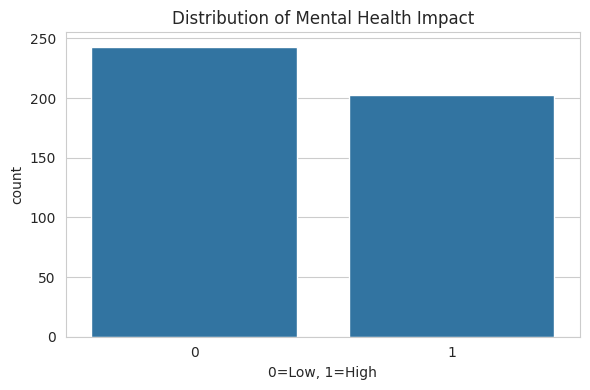

```python
sns.set_style('whitegrid')

plt.figure(figsize=(6, 4))
sns.countplot(x='High_Impact', data=df)
plt.title('Distribution of Mental Health Impact')
plt.xlabel('0=Low, 1=High')
plt.tight_layout()
plt.show()
```

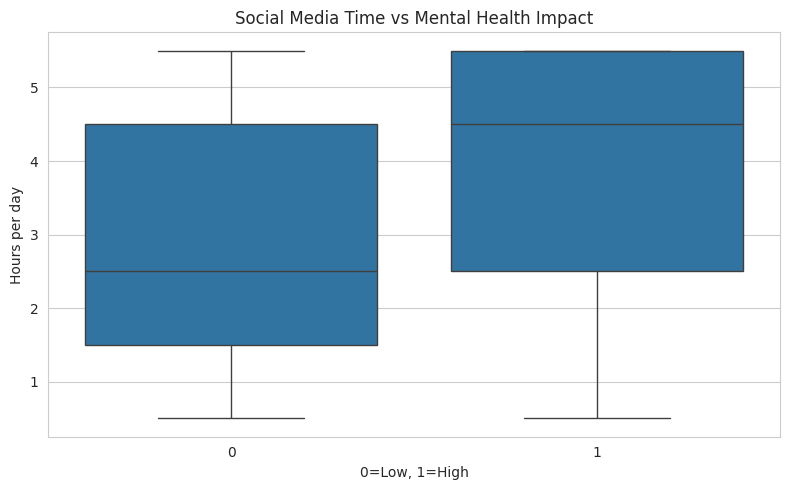

```python
plt.figure(figsize=(8, 5))
sns.boxplot(x='High_Impact', y='Avg_Time', data=df)
plt.title('Social Media Time vs Mental Health Impact')
plt.xlabel('0=Low, 1=High')
plt.ylabel('Hours per day')
plt.tight_layout()
plt.show()
```

High impact group spends a bit more time on social media but theres alot of overlap between the groups. So time alone probaly wont be a strong predictor.

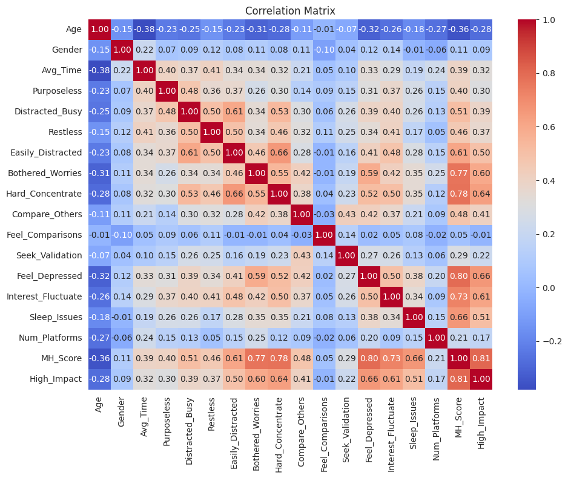

```python
# correlation matrix
plt.figure(figsize=(10, 8))
sns.heatmap(df.corr(), annot=True, fmt='.2f', cmap='coolwarm')
plt.title('Correlation Matrix')
plt.tight_layout()
plt.show()
```

## Modeling

```python
feature_cols = ['Age', 'Gender', 'Avg_Time', 'Num_Platforms', 'Purposeless',
                'Distracted_Busy', 'Restless', 'Easily_Distracted',
                'Compare_Others', 'Feel_Comparisons', 'Seek_Validation']

X = df[feature_cols]
y = df['High_Impact']

X_train, X_test, y_train, y_test = train_test_split(X, y, test_size=0.2, random_state=42, stratify=y)
print(f'Train: {X_train.shape[0]}, Test: {X_test.shape[0]}')
```

```
Train: 356, Test: 90
```

```python
scaler = StandardScaler()
X_train_scaled = scaler.fit_transform(X_train)
X_test_scaled = scaler.transform(X_test)
```

Split 80/20 with stratify so both sets have the same ratio. Scaled with StandardScaler because age goes up to like 30 but the survey questions are 1-5 so without scaling I think the model would weight age too much.

Used fit_transform on training and just transform on test so the test data doesnt effect the scaling.

### Trying 3 models

I went with Logistic Regression, Decision Tree, and Random Forest. We covered these in class and they seemed like a good range from simple to more complex. Used cross validation with 5 folds to compare them.

```python
lr = LogisticRegression(random_state=42, max_iter=1000)
lr_scores = cross_val_score(lr, X_train_scaled, y_train, cv=5, scoring='accuracy')
print(f'Logistic Regression: {lr_scores.mean():.4f}')

dt = DecisionTreeClassifier(random_state=42, max_depth=5)
dt_scores = cross_val_score(dt, X_train_scaled, y_train, cv=5, scoring='accuracy')
print(f'Decision Tree: {dt_scores.mean():.4f}')

rf = RandomForestClassifier(random_state=42, n_estimators=100, max_depth=5)
rf_scores = cross_val_score(rf, X_train_scaled, y_train, cv=5, scoring='accuracy')
print(f'Random Forest: {rf_scores.mean():.4f}')
```

```
Logistic Regression: 0.7697
Decision Tree: 0.7360
Random Forest: 0.7557
```

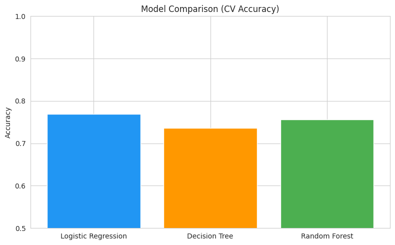

```python
plt.figure(figsize=(8, 5))
plt.bar(['Logistic Regression', 'Decision Tree', 'Random Forest'],
        [lr_scores.mean(), dt_scores.mean(), rf_scores.mean()],
        color=['#2196F3', '#FF9800', '#4CAF50'])
plt.title('Model Comparison (CV Accuracy)')
plt.ylabel('Accuracy')
plt.ylim(0.5, 1.0)
plt.tight_layout()
plt.show()
```

LR got 0.77, DT got 0.74, RF got 0.76. I honestly expected Random Forest to win since it uses 100 trees but I guess with only 446 rows theres not enough data for it to really shine. The simpler model just worked better here which I thought was kinda suprising.

## Results

```python
# LR was best so using that
lr.fit(X_train_scaled, y_train)
lr_pred = lr.predict(X_test_scaled)

print(f'Test Accuracy: {lr.score(X_test_scaled, y_test):.4f}')
print()
print(classification_report(y_test, lr_pred, target_names=['Low Impact', 'High Impact']))
```

```
Test Accuracy: 0.7889

              precision    recall  f1-score   support

  Low Impact       0.80      0.82      0.81        49
 High Impact       0.78      0.76      0.77        41

    accuracy                           0.79        90
   macro avg       0.79      0.79      0.79        90
weighted avg       0.79      0.79      0.79        90
```

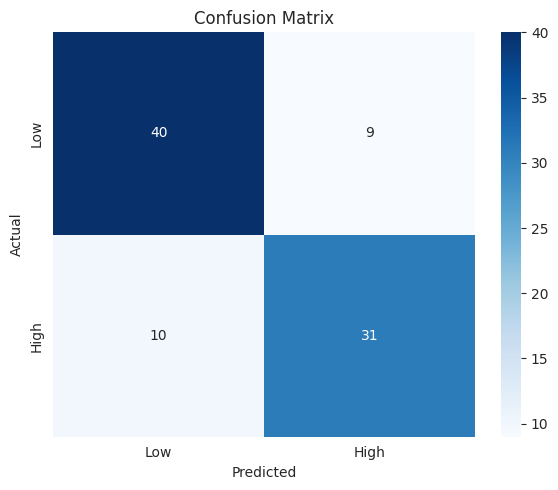

```python
cm = confusion_matrix(y_test, lr_pred)
plt.figure(figsize=(6, 5))
sns.heatmap(cm, annot=True, fmt='d', cmap='Blues',
            xticklabels=['Low', 'High'], yticklabels=['Low', 'High'])
plt.title('Confusion Matrix')
plt.xlabel('Predicted')
plt.ylabel('Actual')
plt.tight_layout()
plt.show()
```

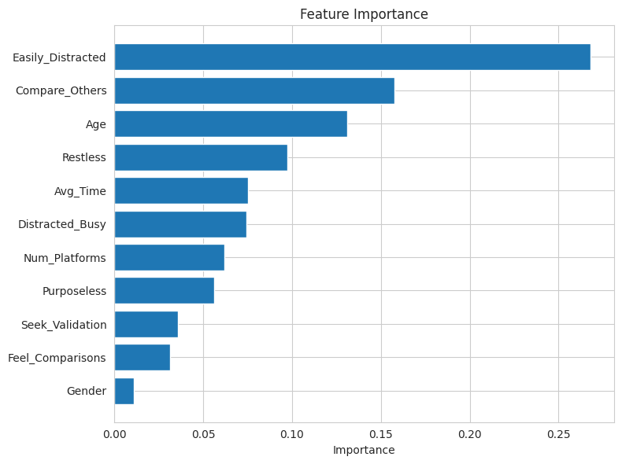

```python
# feature importance
# using random forest for this since LR doesnt have feature_importances_
rf.fit(X_train_scaled, y_train)
feat_imp = pd.DataFrame({'Feature': feature_cols, 'Importance': rf.feature_importances_})
feat_imp = feat_imp.sort_values('Importance', ascending=True)

plt.figure(figsize=(8, 6))
plt.barh(feat_imp['Feature'], feat_imp['Importance'])
plt.title('Feature Importance')
plt.xlabel('Importance')
plt.tight_layout()
plt.show()
```

This was probaly the most intresting part. Its not really about how many hours you spend online, its more about what your doing. If your constantly comparing yourself to people thats worse then just scrolling through stuff. Which kinda makes sense when you think about it.

## Limitations

- Only 446 rows after cleaning so the dataset is small. More data would help
- I made up the target variable by combining questions and splitting at the median, someone else could do it diffrent
- Self reported data so people might exaggerate or underestimate their usage
- 77% accuracy isnt great, wrong about 1 in 4 times

**Ethics:** this shouldnt be used to diagnose anyone or make real decisions about someones mental health. Its just patterns in data.

If I had more time I would try to find a bigger dataset and maybe test more models.

## References

- Dataset: Souvik Ahmed, "Social Media and Mental Health" (Kaggle)
- scikit-learn docs: https://scikit-learn.org/stable/user_guide.html
- pandas docs: https://pandas.pydata.org/docs/
- seaborn docs: https://seaborn.pydata.org/tutorial.html
- DTSC 2301 lectures

## AI Use

I used Claude to help debug my code when stuff wasnt working and to clean up wording. The sklearn and pandas docs were my main references for the code. Claude also helped me put together the website. The decisions about the analysis are mine.